# STAT 440 Statistical Data Management - Fall 2021

## Week 04 Notes

### Created by Christopher Kinson

### Table of Contents

- Arranging data
  - Organizing columns
  - Sorting columns
- Reshaping data
  - Pivoting
  - Transposing

## Arranging data

Arranging a dataset involves organizing its columns and sorting the data by one or more of its columns.

### Organizing columns

Using the tidyverse, organizing the columns can be accomplished with the `select()` function which is within the **dplyr** package. Recall the City of Urbana’s [Rental Inspection Grades Listing Data as tab-separated .txt](https://github-dev.cs.illinois.edu/stat440-fa21/stat440-fa21-course-content/raw/master/data/rental-inspections-grades-data03.txt).

```r
library(tidyverse)
RentalsData <- read_delim("https://raw.github-dev.cs.illinois.edu/stat440-fa21/stat440-fa21-course-content/master/data/rental-inspections-grades-data03.txt?token=AAABJGYPNPRLJDH2JQESWD3BGO3FG", delim="\t")
head(RentalsData)
```

```
## # A tibble: 6 x 7
##   `Property Address`    `Parcel Number` `Inspection Date` Grade `License Status`
##   <chr>                           <dbl> <chr>             <chr> <chr>
## 1 607 1/2 Glover Avenue    922116177018 7/24/2015         Clas~ Expired
## 2 1302 1/2 Hill Street     912107406011 8/17/2011         Clas~ Issued
## 3 212 1/2 Central Aven~    912108383001 4/26/2010         Clas~ Issued
## 4 801 1/2 East Harding~    932121153003 6/12/2013         Clas~ Issued
## 5 1003 1/2 East Hardin~    932121153010 7/8/2013          Clas~ Issued
## 6 1204 1/2 North Goodw~    912107276001 10/20/2011        Clas~ Issued
## # ... with 2 more variables: Expiration Date <chr>, Mappable Address <chr>
```

Let’s arrange the Rental Inspection Grades Listing Data such that:

- the first column is Parcel Number
- the second column is Property Address
- the third column is Mappable Address
- the fourth column is Inspection Date
- the fifth column is Expiration Date
- the sixth column is License Status
- the seventh column is Grade

```r
RentalsData %>%
  select(`Parcel Number`, `Property Address`, `Mappable Address`, `Inspection Date`, `Expiration Date`, `License Status`, Grade) %>%
  head(., 5)
```

```
## # A tibble: 5 x 7
##   `Parcel Number` `Property Address`  `Mappable Address`        `Inspection Dat~
##             <dbl> <chr>               <chr>                     <chr>
## 1    922116177018 607 1/2 Glover Ave~ "607 1 2 Glover Avenue\n~ 7/24/2015
## 2    912107406011 1302 1/2 Hill Stre~ "1302 1 2 Hill Street\nU~ 8/17/2011
## 3    912108383001 212 1/2 Central Av~ "212 1 2 Central Avenue\~ 4/26/2010
## 4    932121153003 801 1/2 East Hardi~ "801 1 2 East Harding Dr~ 6/12/2013
## 5    932121153010 1003 1/2 East Hard~ "1003 1 2 East Harding D~ 7/8/2013
## # ... with 3 more variables: Expiration Date <chr>, License Status <chr>,
## #   Grade <chr>
```

```r
RentalsData2 <- RentalsData %>%
  select(`Parcel Number`, `Property Address`, `Mappable Address`, `Inspection Date`, `Expiration Date`, `License Status`, Grade)

head(RentalsData2, 5)
```

```
## # A tibble: 5 x 7
##   `Parcel Number` `Property Address`  `Mappable Address`        `Inspection Dat~
##             <dbl> <chr>               <chr>                     <chr>
## 1    922116177018 607 1/2 Glover Ave~ "607 1 2 Glover Avenue\n~ 7/24/2015
## 2    912107406011 1302 1/2 Hill Stre~ "1302 1 2 Hill Street\nU~ 8/17/2011
## 3    912108383001 212 1/2 Central Av~ "212 1 2 Central Avenue\~ 4/26/2010
## 4    932121153003 801 1/2 East Hardi~ "801 1 2 East Harding Dr~ 6/12/2013
## 5    932121153010 1003 1/2 East Hard~ "1003 1 2 East Harding D~ 7/8/2013
## # ... with 3 more variables: Expiration Date <chr>, License Status <chr>,
## #   Grade <chr>
```

*SN: The pipe operator `%>%` comes with the tidyverse package and is a neat way to complete multiple lines of code and nesting of functions without doing all that. It takes the first code on the left side of the first pipe operator and places it into a pipeline of operations. Our code above can be translated in laypeople’s terms as "beginning with `RentalsData` and then select these columns and then show the first 5 rows of the result.*

Also, notice that in order to store the newly arranged data, we need to assign the data with the assignment operator.

### Sorting columns

Sorting the data by the values in the columns involves the tidyverse’s `arrange()` function (**dplyr** package). Now let’s sort the data such that the Parcel Numbers are in ascending order showing the resulting first 10 rows.

```r
RentalsData2 %>%
  arrange(`Parcel Number`) %>%
  head(., 10)
```

```
## # A tibble: 10 x 7
##    `Parcel Number` `Property Address` `Mappable Address`        `Inspection Dat~
##              <dbl> <chr>              <chr>                     <chr>
##  1    912104351004 1902 Willow Road   "1902 Willow Road\nUrban~ 5/21/2010
##  2    912105477028 1601 Willow Road   "1601 Willow Road\nUrban~ 10/19/2007
##  3    912105477030 1709 Willow Court  "1709 Willow Court\nUrba~ 7/27/2010
##  4    912105477031 1707 Willow Court  "1707 Willow Court\nUrba~ 7/13/2010
##  5    912105477032 1705 Willow Court  "1705 Willow Court\nUrba~ 7/13/2010
##  6    912105477033 1703 Willow Court  "1703 Willow Court\nUrba~ 7/13/2010
##  7    912107201001 1405 Bradley Aven~ "1405 Bradley Avenue\nUr~ 2/17/2012
##  8    912107202007 1507 North Romine~ "1507 North Romine Stree~ 7/27/2011
##  9    912107203001 1305 Bradley Aven~ "1305 Bradley Avenue\nUr~ 7/15/2011
## 10    912107203003 1506 North Romine~ "1506 North Romine Stree~ 10/22/2013
## # ... with 3 more variables: Expiration Date <chr>, License Status <chr>,
## #   Grade <chr>
```

We can complicate this arrangement by specifying the sort order of more columns. Let’s sort the Rental Inspection Grades Listing Data such that the Grades in descending order then Parcel Numbers are in ascending order and showing the resulting first 10 rows.

```r
RentalsData2 %>%
  arrange(desc(Grade), `Parcel Number`) %>%
  head(., 10)
```

```
## # A tibble: 10 x 7
##    `Parcel Number` `Property Address` `Mappable Address`        `Inspection Dat~
##              <dbl> <chr>              <chr>                     <chr>
##  1    922117111001 611 West Elm Stre~ "611 West Elm Street\nUr~ 2/12/2019
##  2    932121181018 1302 Silver Street "1302 Silver Street\nUrb~ 2/25/2013
##  3    932121181019 1304 Silver Street "1304 Silver Street\nUrb~ 2/25/2013
##  4    922117264013 709 1/2 South Vin~ "709 1 2 South Vine Stre~ 12/7/2009
##  5    932117476001 1304 South Vine S~ "1304 South Vine Street\~ 5/27/2016
##  6    932121181020 1306 East Silver ~ "1306 East Silver Street~ 4/11/2017
##  7    912107205012 1407 North Romine~ "1407 North Romine Stree~ 4/19/2016
##  8    912107253008 1410 Beslin Street "1410 Beslin Street\nUrb~ 7/12/2011
##  9    912107255007 1308 Beech Street  "1308 Beech Street\nUrba~ 6/27/2011
## 10    912107256012 1003 North Mathew~ "1003 North Mathews Aven~ 6/16/2011
## # ... with 3 more variables: Expiration Date <chr>, License Status <chr>,
## #   Grade <chr>
```

## Reshaping data

Reshaping a dataset can be a good way to ensure the information we want is in the proper orientation. Two actions usually encompass reshaping: pivoting and transposing. The particular action being taken ultimately depends on the scenario.

## Pivoting

Pivoting may happen in two ways:

1. “lengthening”, which makes the dataset longer (more rows than we started). See image taken from [RStudio’s dplyr cheat sheet](https://rstudio.com/wp-content/uploads/2015/02/data-wrangling-cheatsheet.pdf).

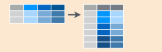

2. “widening”, which makes the dataset wider (more columns than we started). See image taken from [RStudio’s dplyr cheat sheet](https://rstudio.com/wp-content/uploads/2015/02/data-wrangling-cheatsheet.pdf)

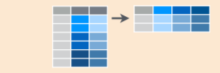

To prepare the data for pivoting, we are adding two columns to the City of Urbana’s [Rental Inspection Grades Listing Data as tab-separated .txt](https://github-dev.cs.illinois.edu/stat440-fa21/stat440-fa21-course-content/raw/master/data/rental-inspections-grades-data03.txt) (named object `RentalsData`). *Pivoting may not be necessary with the original `RentalsData`.*

```r
Coordinates<-str_split(RentalsData$`Mappable Address`, "\\\n", simplify = TRUE)[,3]
Coordinates00 <- str_remove_all(Coordinates, "\\)|\\,|\\(")
Coordinates000 <- str_split(Coordinates00, " ", simplify = TRUE)
RentalsData$Coordinates01 <- Coordinates000[,1]
RentalsData$Coordinates02 <- Coordinates000[,2]
```

With this new version of the City of Urbana’s Rental Inspection Grades Listing Data, suppose that we wanted the decimal values in columns Coordinates01 and Coordinates02 in a single column. To accomplish this, we can use the `pivot_longer()` function (within the **tidyverse**; **dplyr**) since would be making the data longer; we’re adding more rows than there were originally.

```r
RentalsData3 <- RentalsData %>%
  pivot_longer(cols=c(Coordinates01,Coordinates02), names_to="Coordinate", values_to="Decimal" )

head(RentalsData3)
```

```
## # A tibble: 6 x 9
##   `Property Address`   `Parcel Number` `Inspection Date` Grade  `License Status`
##   <chr>                          <dbl> <chr>             <chr>  <chr>
## 1 607 1/2 Glover Aven~    922116177018 7/24/2015         Class~ Expired
## 2 607 1/2 Glover Aven~    922116177018 7/24/2015         Class~ Expired
## 3 1302 1/2 Hill Street    912107406011 8/17/2011         Class~ Issued
## 4 1302 1/2 Hill Street    912107406011 8/17/2011         Class~ Issued
## 5 212 1/2 Central Ave~    912108383001 4/26/2010         Class~ Issued
## 6 212 1/2 Central Ave~    912108383001 4/26/2010         Class~ Issued
## # ... with 4 more variables: Expiration Date <chr>, Mappable Address <chr>,
## #   Coordinate <chr>, Decimal <chr>
```

That’s it! We just increased the number of rows of `RentalsData` to 3460.

Now, with this newly pivoted data, let’s demonstrate “widening” the data. In this way, we want to increase the number of columns; essentially reverting back to the version of the data before “lengthening.” *Notice that we first use the `arrange()` function to sort the Coordinate column.*

```r
RentalsData4 <- RentalsData3 %>%
  arrange(Coordinate) %>%
  pivot_wider(names_from = Coordinate, values_from = Decimal)

head(RentalsData4)
```

```
## # A tibble: 6 x 9
##   `Property Address`    `Parcel Number` `Inspection Date` Grade `License Status`
##   <chr>                           <dbl> <chr>             <chr> <chr>
## 1 607 1/2 Glover Avenue    922116177018 7/24/2015         Clas~ Expired
## 2 1302 1/2 Hill Street     912107406011 8/17/2011         Clas~ Issued
## 3 212 1/2 Central Aven~    912108383001 4/26/2010         Clas~ Issued
## 4 801 1/2 East Harding~    932121153003 6/12/2013         Clas~ Issued
## 5 1003 1/2 East Hardin~    932121153010 7/8/2013          Clas~ Issued
## 6 1204 1/2 North Goodw~    912107276001 10/20/2011        Clas~ Issued
## # ... with 4 more variables: Expiration Date <chr>, Mappable Address <chr>,
## #   Coordinates01 <chr>, Coordinates02 <chr>
```

Done! Technically the number of columns did not increase, but the number of rows did decrease. This is another way to know that the “widening” worked appropriately.

## Transposing

When it comes to transposing, all we’re accomplishing is making the columns become the rows, alternating the dimension of the data: formerly row## by column## to presently column## by row##.

```r
RentalsData5 <- t(RentalsData)

dim(RentalsData)
```

```
## [1] 1730    9
```

```r
dim(RentalsData5)
```

```
## [1]    9 1730
```

We see the data went from 1730 by 9 to presently 9 by 1730.